# Developing Data Products

Chuck Chekuri

4/4/2017

# Simple, Easy and Powerful

Using RStudio and R, developing a simple predictive application can’t get any better.  
This presentation shows how samll the effort to develop a fully functioning data product.

All it took was:

- Three simple steps, a few Lines of code and
- Two hours from conception to completion.

It’s amazing how quickly and effectively one can develop a predictive application.  
The next two slides show the effort and the final data product.

You can check out the application at: https://cc92887.shinyapps.io/stockprediction/

Github repo: https://github.com/ChuckChekuri/datasciencecoursera/tree/master/DataProductsFinal/StockPrediction

# The Effort

All data product have these three steps and this is no different.

- Get the data from the internet
- Describe the UI
- React to user input

Shiny and the R libraries take care of all the deails of rendering, connecting, synchronzing and appearance.

# The Data Product

The product displayes the Stock data and predicts what the close will be the next day.

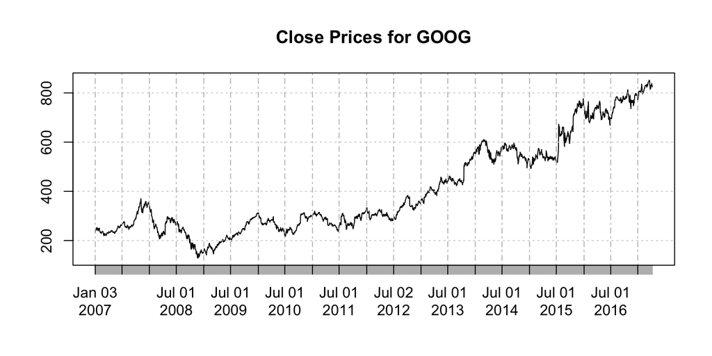

| Prediction | Low80 | Low95 | High80 | High95 |
| --- | --- | --- | --- | --- |
| 824.8987 | 816.2240 | 811.6318 | 833.5735 | 838.1656 |
| 825.1275 | 812.8595 | 806.3653 | 837.3955 | 843.8897 |

# Conclusion

R is so powerful and easy to use, it is going to change the way we develop data products and the pace with which apps will be developed will be amazing.

R, Shiny and R Studio will do what Apple’s App Store did to the mobile application market.